# Environments

Byron Tang

June 2, 2018

## Environment basics

1. List three ways in which an environment differs from a list.

```
## 1. Every name in an environment is unique.
## 2. The names in an environment are not ordered (i.e., it does not make sense to ask what the first element of an environment is).
## 3. An environment has a parent.
## 4. Environments have reference semantics.
```

2. If you don’t supply an explicit environment, where do ls() and rm() look? Where does <- make bindings?

```
## ls() and rm() default to the current environment if an environment is not specified.
##
## The operators <- assigns into the environment in which they are evaluated.
```

3. Using parent.env() and a loop (or a recursive function), verify that the ancestors of globalenv() include baseenv() and emptyenv(). Use the same basic idea to implement your own version of search().

## Recursing over environemnts

```r
search()
```

```
##  [1] ".GlobalEnv"        "package:knitr"     "package:pryr"
##  [4] "package:stats"     "package:graphics"  "package:grDevices"
##  [7] "package:utils"     "package:datasets"  "package:methods"
## [10] "Autoloads"         "package:base"
```

```r
rec_env <- function(env){
  if (is.null(attr(env, "name"))) {
    print(env)
  } else {
    print(attr(env, "name"))
  }
  if (identical(env, baseenv()))
    return(emptyenv())
  return(rec_env(parent.env(env = env)))
}
# print(environment())
rec_env(environment())
```

```
## <environment: R_GlobalEnv>
## [1] "package:knitr"
## [1] "package:pryr"
## [1] "package:stats"
## [1] "package:graphics"
## [1] "package:grDevices"
## [1] "package:utils"
## [1] "package:datasets"
## [1] "package:methods"
## [1] "Autoloads"
## <environment: base>
```

```
## <environment: R_EmptyEnv>
```

### Recursing over environments

1. Modify where() to find all environments that contain a binding for name.

```r
# Create a new function
where_new <- function(name, env = parent.frame()) {
  # A function that is similar to where() but lives in the function
  # in order to behave differently for objects that exist
  where_in <- function(name, env) {
      # success case
      if (exists(name, envir = env, inherits = FALSE)) {
        print(env)
        # base case
        if (identical(parent.env(env), emptyenv())) {
          return("End of Search")
        } else {
          where_in(name, parent.env(env))
        }
      } else {
        # recursive case
        if (identical(parent.env(env), emptyenv())) {
          return("End of Search")
        } else {
          where_in(name, parent.env(env))
        }
      }
  }
  if (!exists(name, envir = env, inherits = TRUE)) {
    paste("Can't find ", name)
  } else {
    where_in(name, env)
  }
}
```

```r
# Create objects and new environments
  # global environment
a <- 1

  # global + 1 level of new env
e <- new.env()
e$a <- 2

  # global + 2 levels of new env
e2 <- new.env(parent = e)
e2$a <- 3

# Test
message("Search for 'a' by where function")
```

```
## Search for 'a' by where function
```

```r
where("a", env = e2)
```

```
## <environment: 0x000000001c058178>
```

```r
message("\nSearch for 'a' by new where function")
```

```
##
## Search for 'a' by new where function
```

```r
where_new("a", env = e2)
```

```
## <environment: 0x000000001c058178>
## <environment: 0x000000001bf96998>
## <environment: R_GlobalEnv>
```

```
## [1] "End of Search"
```

```r
message("\nSearch for 'b'")
```

```
##
## Search for 'b'
```

```r
where_new("b", env = e2)
```

```
## [1] "Can't find  b"
```

2. Write your own version of get() using a function written in the style of where().

```r
get_new <- function(name, env = parent.frame()) {
  if (identical(env, emptyenv())) {
    # Base case
    paste("Can't find ", name)

  } else if (exists(name, envir = env, inherits = FALSE)) {
    # Success case
    print(env)
    .Internal(get(name, env, mode = "any", inherits = FALSE))

  } else {
    # Recursive case
    get_new(name, parent.env(env))
  }
}
```

```r
# Test
message("Get 'a' with the original get function")
```

```
## Get 'a' with the original get function
```

```r
get("a", env = e2)
```

```
## [1] 3
```

```r
message("\nGet 'a' with the new get function")
```

```
##
## Get 'a' with the new get function
```

```r
get_new("a", env = e2)
```

```
## <environment: 0x000000001c058178>
```

```
## [1] 3
```

```r
message("\nTest recursive case in the new get function")
```

```
##
## Test recursive case in the new get function
```

```r
c <- 10
get_new("c", env = e2)
```

```
## <environment: R_GlobalEnv>
```

```
## [1] 10
```

3. Write a function called fget() that finds only function objects. It should have two arguments, name and env, and should obey the regular scoping rules for functions: if there’s an object with a matching name that’s not a function, look in the parent. For an added challenge, also add an inherits argument which controls whether the function recurses up the parents or only looks in one environment.

```r
# The current fget function has met the criteria of the question
fget
```

```
## function (name, env = parent.frame())
## {
##     env <- to_env(env)
##     if (identical(env, emptyenv())) {
##         stop("Could not find function called ", name, call. = FALSE)
##     }
##     if (exists(name, env, inherits = FALSE) && is.function(env[[name]])) {
##         env[[name]]
##     }
##     else {
##         fget(name, parent.env(env))
##     }
## }
## <bytecode: 0x0000000017b20338>
## <environment: namespace:pryr>
```

```r
# Create a new function with an inherits argument
fget_new <- function (name, env = parent.frame(), inherits = TRUE)
{
    #env <- to_env(env)
    if (inherits) {
      if (identical(env, emptyenv())) {
          stop("Could not find function called ", name, call. = FALSE)
      }
      if (exists(name, env, inherits = FALSE) && is.function(env[[name]])) {
          env[[name]]
      }
      else {
          fget_new(name, parent.env(env))
      }
    } else {
      if (exists(name, env, inherits = FALSE) && is.function(env[[name]])) {
          env[[name]]
      }
      else {
          paste("Counld not find function called", name)
      }
    }
}
```

```r
# Test
fget("sum")
```

```
## function (..., na.rm = FALSE)  .Primitive("sum")
```

```r
fget_new("sum")
```

```
## function (..., na.rm = FALSE)  .Primitive("sum")
```

```r
fget_new("sum", inherits = FALSE)
```

```
## [1] "Counld not find function called sum"
```

4. Write your own version of exists(inherits = FALSE) (Hint: use ls().) Write a recursive version that behaves like exists(inherits = TRUE).

```r
exists_new <- function(name, env = parent.frame(), inherits = FALSE) {
    if (inherits) {
      if (identical(env, emptyenv())) {
          return(FALSE)
      }
      if (exists(name, env, inherits = FALSE)) {
          return(TRUE)
      }
      else {
          exists_new(name, parent.env(env), inherits = TRUE)
      }
    } else {
      if (exists(name, env, inherits = FALSE)) {
          return(TRUE)
      }
      else {
          return(FALSE)
      }
    }
}
```

```r
# Test
exists("c") # Expects TRUE
```

```
## [1] TRUE
```

```r
exists("sum") # Expects TRUE
```

```
## [1] TRUE
```

```r
exists("b") # Expects FALSE
```

```
## [1] FALSE
```

```r
exists_new("c") # Expects TRUE
```

```
## [1] TRUE
```

```r
exists_new("sum") # Expects FALSE
```

```
## [1] FALSE
```

```r
exists_new("sum", inherits = TRUE) # Expects TRUE
```

```
## [1] TRUE
```

```r
exists("b", inherits = TRUE) # Expects FALSE
```

```
## [1] FALSE
```

## Function environments

Notes:

```r
e$g <- function() 1 # The function is created in the global environment
environment(e$g) # Therefore, the enclosing environement is still global.
```

```
## <environment: R_GlobalEnv>
```

```r
where("g", env = e) # However, the binding environment is e.
```

```
## <environment: 0x000000001bf96998>
```

A function is created (enclosed) in a namespace (the imports) but bound in a package (the exports). More reference about namespace: http://r-pkgs.had.co.nz/namespace.html

```r
environment(sd)
```

```
## <environment: namespace:stats>
```

```r
where("sd")
```

```
## <environment: package:stats>
## attr(,"name")
## [1] "package:stats"
## attr(,"path")
## [1] "C:/Program Files/R/R-3.5.0/library/stats"
```

```r
h <- function() {
  x <- 10
  function() {
    x
  }
}
i <- h()
x <- 20
i()
```

```
## [1] 10
```

1. List the four environments associated with a function. What does each one do? Why is the distinction between enclosing and binding environments particularly important?

```
## 1. Enclosing environments: The enclosing environment is the environment where the function was created.
## 2. Binding environments: The binding environments of a function are all the environments which have a binding to it.
## 3. Execution environments: Each time a function is called, a new environment is created to host execution. Once the function has completed, this environment is thrown away.
## 4. Calling environments: The environment where the function is called.
##
## The distinction between the binding environment and the enclosing environment is important for package namespaces. Package namespaces keep packages independent.
```

2. Draw a diagram that shows the enclosing environments of this function:

f1 <- function(x1) { f2 <- function(x2) { f3 <- function(x3) { x1 + x2 + x3 } f3(3) } f2(2) } f1(1)

3. Expand your previous diagram to show function bindings.
4. Expand it again to show the execution and calling environments.

```r
message("The below graph contains answers for exercise 2 to 4:")
```

```
## The below graph contains answers for exercise 2 to 4:
```

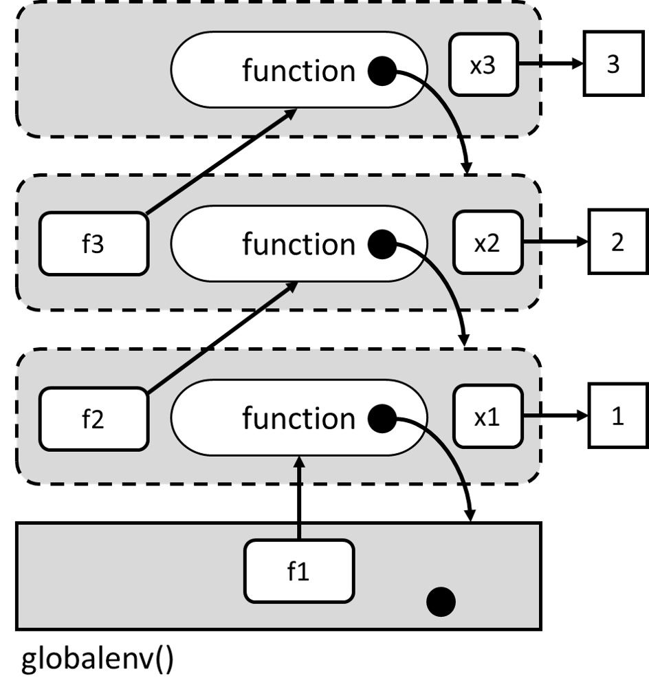

```r
include_graphics("C:/Users/byron/Documents/GitHub/advanced-R-exercises/FunctionEnvironmentsEx2.png")
```

5. Write an enhanced version of str() that provides more information about functions. Show where the function was found and what environment it was defined in.